# Entorno Económico y Financiero para las Decisiones de Inversión

Clase 01: Nivel de actividad, mercado laboral y variables nominales

octubre 2026

# Presentación del curso

## Equipo docente

**Docentes:**

- Sebastián Egaña Santibáñez

**Ayudante:**

- Jean Pierre Bravo

## Contenidos del curso

- Análisis de principales variables macroeconómicas
- Políticas macroeconómicas
- Revisión de modelos de mercado de bienes y de activos financieros
- Comportamiento de los agentes económicos: consumo y gobierno

## Sobre el docente

**Sebastián Egaña Santibáñez**

- Data Tech Lead & Data Scientist — LATAM Airlines
- Correo: segana@fen.uchile.cl
- Web: https://segana.netlify.app
- LinkedIn: [enlace](https://www.linkedin.com/in/sebastian-egana-santibanez/)

## Hilo conductor de la clase

Partimos con un titular (actividad `clase01_actividad_01_apertura`). Al terminar la sesión deberían poder leerlo con precisión.

“US inflation tripled last month on record spike in gas prices”

— CNN Business, 10 de abril de 2026

Para entenderlo necesitamos saber qué mide el IPC, cómo se construye, qué tan grave es un alza mensual de 0,9%, y cómo conecta con el empleo, el crecimiento y el tipo de cambio.

## ¿Qué veremos esta clase?

| Bloque | Conceptos clave |
| --- | --- |
| Entorno económico | Variables que afectan decisiones |
| Nivel de actividad | PIB, Imacec, bienestar |
| Mercado laboral | Clasificación, tasas, Okun |
| Variables nominales y reales | IPC, deflactor, salario real, tipo de cambio |
| Estabilidad financiera y holguras fiscales | Balance estructural, deuda pública y sistema financiero (CFA, IEF, 2026) |

# Entorno Económico

## ¿Por qué importa el entorno?

El entorno económico es el conjunto de variables económicas y financieras que influyen en la toma de decisiones de personas, empresas y gobiernos.

- El **crecimiento económico** se relaciona con el desempeño de los mercados
- La **inflación** erosiona el poder adquisitivo y encarece los costos de las empresas
- El **tipo de cambio** afecta directamente a importadores y exportadores
- La **tasa de interés** determina el costo del financiamiento

> No se puede tomar una decisión de inversión sin leer el entorno. Los indicadores macroeconómicos son el lenguaje en que ese entorno habla.

## Chile en 2026: punto de partida

| Indicador | Dato | Fuente |
| --- | --- | --- |
| Crecimiento PIB 2025 | **+2,5%** real | IPoM, BCCh, sep. 2026, Tabla 3 |
| Proyección PIB 2026 | **0,25 – 0,75%** (en junio: 1,0 – 1,75%) | IPoM, BCCh, sep. 2026, p. 6 |
| Inflación (últimos meses) | **~4%** anual | IPoM, BCCh, sep. 2026, p. 15 |
| Inflación proyectada (dic. 2026) | **4,3%** | IPoM, BCCh, sep. 2026, Tabla 1 |
| Tasa de desocupación | **9,5%** (9,3% desestacionalizada) | IPoM, BCCh, sep. 2026, p. 5 |
| Precio del cobre | US$6,1/lb proyectado para 2026 | IPoM, BCCh, sep. 2026, Tabla 2 |
| Precio del petróleo | ~US$90/barril al cierre del informe | IPoM, BCCh, sep. 2026, p. 10 |

El shock dominante de 2026 es la **guerra en Medio Oriente** (inicio: 28 feb.), que presiona la energía y la inflación, mientras la **demanda interna se desacelera** y el empleo se deteriora.

# Nivel de Actividad

## ¿Qué mide el nivel de actividad?

Cuando hablamos de nivel de actividad, preguntamos por la producción de una economía. Las métricas principales son:

- **PIB** (Producto Interno Bruto): valor de la producción **final** de bienes y servicios **dentro del territorio** en un período
- **PNB** (Producto Nacional Bruto): producción generada con factores (trabajo y capital) **de propiedad de nacionales**, estén donde estén

El ajuste refleja la diferencia entre dónde se produce y quién lo produce.

## Tres palabras clave del PIB

**Producción:** solo bienes y servicios nuevos — no transferencias, no activos financieros.

**Final:** no se cuentan los bienes intermedios para evitar la doble contabilidad.

**Fronteras:** el PIB captura lo que pasa dentro del país, independiente de la nacionalidad del productor.

> Actividad: ¿Cuenta o no cuenta en el PIB? Ver `clase01_actividad_02_pib`

## 3 formas de medición

Los tres métodos deben dar el mismo resultado — son tres ventanas al mismo fenómeno:

1. **Por el lado del gasto** (la más usada y citada)
2. **Por el valor agregado o producción** — así se calcula el Imacec
3. **Por el lado de los ingresos**

Por el lado del gasto:

$$PIB = C + I + G + (X - M)$$

Donde C = consumo, I = inversión, G = gasto de gobierno, X = exportaciones, M = importaciones.

## Por el lado de la producción: valor agregado

El **valor agregado bruto (VAB)** de una empresa es el valor de lo que produce menos lo que compra a otras empresas para producir (consumo intermedio).

> **Valor agregado no significa utilidad.** De ese valor todavía se pagan remuneraciones y otros componentes del ingreso generado por la producción.

*Ejemplo, el pan de $250:*

| Etapa | Vende por | Compra insumos por | Valor agregado |
| --- | --- | --- | --- |
| Agricultor (trigo) | $100 | $0 | $100 |
| Molino (harina) | $160 | $100 | $60 |
| Panadería (pan) | $250 | $160 | $90 |
| **Total** |  |  | **$250** |

La suma de los valores agregados es igual al valor del pan final: no se cuenta dos veces el trigo ni la harina.

## Del valor agregado al PIB a precios de mercado

Para expresar el PIB a precios de mercado, la fórmula completa es:

$$\boxed{\begin{aligned} PIB = {} & \sum VAB_{\text{a precios básicos}} \\ & + \text{impuestos sobre los productos} \\ & - \text{subvenciones sobre los productos} \end{aligned}}$$

El ajuste permite pasar de la valoración de los productores a los precios de mercado.

## Por el lado de los ingresos

Este enfoque pregunta **cómo se distribuye el valor generado** durante la producción.

$$\boxed{\begin{aligned} PIB = {} & \text{remuneraciones} + \text{excedente bruto de explotación} \\ & + \text{ingreso mixto bruto} \\ & + \text{impuestos netos de subvenciones sobre producción y productos} \end{aligned}}$$

| Componente | Qué representa |
| --- | --- |
| Remuneraciones | Sueldos, salarios y contribuciones sociales de los empleadores |
| Excedente bruto de explotación | Ingreso generado por la producción que corresponde al capital, antes de descontar el consumo de capital fijo. No equivale exactamente a la utilidad contable |
| Ingreso mixto bruto | Ingreso de negocios de hogares donde es difícil separar la remuneración del trabajo del dueño y el rendimiento de su capital |
| Impuestos netos de subvenciones | Impuestos sobre la producción y los productos, menos las subvenciones correspondientes |

## Excedente bruto de explotación (EBE)

El **excedente bruto de explotación (EBE)** es el ingreso que queda de la producción después de descontar los insumos utilizados, las remuneraciones de los trabajadores y los otros impuestos sobre la producción, netos de subvenciones.

> En el ejemplo del pan, el agricultor genera un valor agregado de $100 y paga $60 de remuneraciones: su EBE es $40.

## Ingreso mixto y “bruto”

**Ingreso mixto:** el ingreso de una persona que trabaja en su propio almacén mezcla su trabajo y el rendimiento del negocio; de ahí el término *mixto*.

**Bruto:** la palabra indica que se incluye el **consumo de capital fijo**, asociado al desgaste y la obsolescencia de los activos productivos.

> Si se usan excedente e ingreso mixto **netos**, hay que añadir ese consumo de capital fijo por separado.

## Un ejemplo que conecta las tres miradas: ingresos

Volvamos al pan de $250. Supongamos que toda la cadena es nacional, el pan se vende a hogares y no hay impuestos ni subvenciones.

El valor agregado de $250 se distribuye así:

| Etapa | Remuneraciones | Excedente bruto | Valor agregado |
| --- | --- | --- | --- |
| Agricultor | $60 | $40 | $100 |
| Molino | $40 | $20 | $60 |
| Panadería | $70 | $20 | $90 |
| **Total** | **$170** | **$80** | **$250** |

## Tres enfoques, un mismo PIB

| Enfoque | Cálculo | PIB |
| --- | --- | --- |
| Gasto | Los hogares compran el pan final | $250 |
| Producción | $100 + $60 + $90 de valor agregado | $250 |
| Ingresos | $170 de remuneraciones + $80 de excedente bruto | $250 |

La misma producción se observa como **una compra de pan**, **valor creado en una cadena productiva** e **ingresos generados** para quienes participaron en ella.

## Una identidad contable, no una causa

La igualdad es una **identidad contable**, no una afirmación causal.

Escribir $PIB = C + I + G + X - M$ no demuestra que aumentar cualquiera de sus componentes haga subir automáticamente el PIB en la misma cantidad.

> Para eso hay que analizar cómo reaccionan la producción, los precios, las importaciones y el resto de la economía.

## El Imacec: actividad en tiempo real

El PIB se publica trimestralmente y con desfase. Para tener información más reciente, el Banco Central de Chile publica el **Imacec** (Índice Mensual de Actividad Económica) con ~30 días de retraso.

Se calcula por el **método de valor agregado** y sirve como termómetro mensual de la economía.

En 2025, el PIB creció **2,5% real** — coherente con lo que el Imacec fue mostrando mes a mes.

> Fuente: [Banco Central de Chile — Imacec](https://www.bcentral.cl) · [Encuesta de Expectativas Económicas, BCCh](https://www.bcentral.cl)

## PIB y bienestar

El PIB per cápita aproxima la relación entre la productividad del país y la situación de su población:

$$\text{PIB per cápita} = \frac{PIB}{\text{Población}}$$

**Sus limitaciones son conocidas:**

- No captura el trabajo doméstico ni la economía informal
- No distingue el valor de mercado del valor social (externalidades)
- No captura la **distribución** del ingreso

> El PIB puede crecer y la mayoría de la población puede no sentirlo.

## Más allá del PIB

Indicadores complementarios:

- **Índice de Gini:** mide la desigualdad en la distribución del ingreso
- **IDH (PNUD):** combina ingreso, educación y esperanza de vida
- **Índice de Bienestar de la OCDE:** considera trabajo, salud, vivienda, comunidad
- **PIB Verde:** ajustado por degradación ambiental

> ¿Qué indicador usarían para saber si un país “va bien”?

# Mercado Laboral

## Relación con la actividad

Un país con mayor actividad tiende a generar más empleo y mejores salarios. La otra cara es el **desempleo**.

**Definición:** Mercado donde interactúan empleador y empleado, coordinando sus incentivos a través de un salario determinado por el mercado.

> ¿Quién es el oferente y quién es el demandante en el mercado laboral?

## Interacciones dentro de la empresa

| Departamento | La empresa sabe | Determina |
| --- | --- | --- |
| Recursos Humanos | Precios, salarios y empleabilidad externa | Salario nominal, W |
| Marketing | Lo anterior y demanda de sus productos | Precio de venta, P |
| Producción | Lo anterior, productividad y ventas posibles | Empleo, n |

## Clasificación de la población

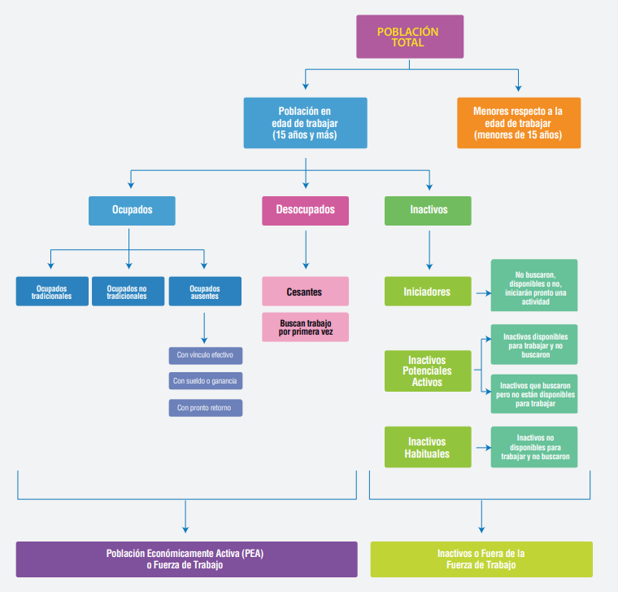

## Definiciones clave (INE)

- **Ocupados:** dedicaron al menos 1 hora en la semana de referencia a producir bienes o servicios a cambio de remuneración
- **Desocupados:** no ocupados, buscaron trabajo activamente en las últimas 4 semanas y están disponibles para trabajar en las próximas 2
- **Inactivos:** en edad de trabajar pero no clasificados como ocupados ni desocupados

> El **trabajador desalentado** es inactivo — quiere trabajar pero dejó de buscar. Esto hace que la tasa oficial **subestime** el desempleo real.

## Criterios de clasificación

**Ocupados** — criterios simultáneos:

| Criterio | Período de referencia |
| --- | --- |
| Producir un bien o servicio | Semana de referencia |
| Al menos 1 hora de actividad | Semana de referencia |
| Recibir remuneración o beneficio | El pago puede ser posterior |

**Desocupados** — criterios simultáneos:

| Criterio | Período de referencia |
| --- | --- |
| No haber trabajado al menos 1 hora | Semana de referencia |
| Búsqueda activa de trabajo | Últimas 4 semanas |
| Disponibilidad para trabajar | Próximas 2 semanas |

## Indicadores del mercado laboral

$$TP = \frac{\text{Fuerza de trabajo}}{\text{Población en edad de trabajar}}$$

$$TO = \frac{\text{Ocupados}}{\text{Población en edad de trabajar}}$$

$$u = \frac{\text{Desocupados}}{\text{Fuerza de trabajo}}$$

La tasa de desempleo también puede escribirse como:

$$u = \frac{FT - n}{FT}$$

donde $n$ es el número de ocupados.

## En números: Noruega vs. España (2025)

| Millones de personas, 15 a 64 años | Noruega | España |
| --- | --- | --- |
| Población en edad de trabajar | 3,6 | 32,5 |
| Fuerza de trabajo | 2,9 | 24,4 |
| Inactivos | 0,7 | 8,2 |
| Ocupados | 2,8 | 21,8 |
| Desocupados | 0,1 | 2,6 |
| Tasa de participación | 80% | 75% |
| Tasa de empleo | 77% | 67% |
| Tasa de desempleo | **4,6%** | **10,6%** |

Fuente: Eurostat, Encuesta de Fuerza de Trabajo de la UE, promedio anual 2025, ambos sexos (tablas `lfsa_pganws`, `lfsa_agan`, `lfsa_egan` y `lfsa_ugan`), consultada el 25 de octubre de 2026. Las tasas se calculan con las cifras originales en miles de personas; las cifras en millones pueden no sumar por redondeo.

## Ley de Okun

Existe una relación negativa entre el nivel de actividad y el desempleo:

$$u_t - u_{t-1} = \mu - (y_t - y_{t-1})$$

O también: $\Delta u \approx \mu - \Delta y$

Un mayor crecimiento del PIB reduce la tasa de desempleo — y viceversa.

> El problema va más allá de la ecuación: importa la **fuente del crecimiento**. Un boom minero genera poco empleo directo. Un boom de servicios genera mucho más.

## ¿Es normal el desempleo?

Un desempleo de 0% implicaría que:

- Perder el trabajo no tiene costo — se encontraría otro de inmediato
- No habría búsqueda de primer empleo
- No habría fricciones ni tiempo de transición entre trabajos

El **desempleo friccional** es estructural a toda economía de mercado: refleja el tiempo que toma emparejar oferta y demanda de trabajo.

## El costo no monetario del desempleo

> Clark y Oswald (2002): un británico promedio necesitaría recibir **£15.000** para compensar la pérdida de un trabajo que reportaba **£2.000** de ingreso.

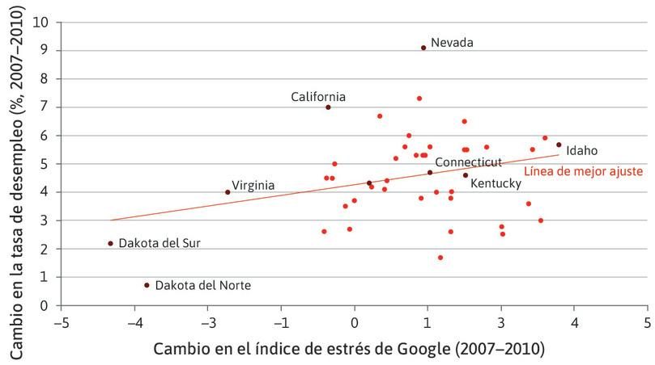

Fuente: [The Economy, Core Econ](https://www.core-econ.org/the-economy/book/es/text/13.html)

## El trabajo en el Marxismo

**Premisa:** En la sociedad capitalista, hay quienes solo pueden vender su trabajo para sobrevivir y quienes pueden comprar trabajo ajeno — de ahí nace el capital.

El concepto central es la **plusvalía** ($s$): el valor que el trabajador genera por sobre lo que recibe como salario.

$$Mercancía = c + v + s$$

$$\text{Tasa de plusvalía} = \frac{s}{v}$$

Donde $c$ = capital constante (maquinaria), $v$ = capital variable (trabajadores).

## Ejemplo numérico: plusvalía

Empresa: US$80 en maquinaria ($c$), US$50 en salarios ($v$), vende por US$150.

$$s = 150 - (80 + 50) = 20 \quad \Rightarrow \quad \frac{s}{v} = \frac{20}{50} = 0{,}4$$

Por cada peso pagado en salarios, el empresario se queda con **40 centavos** de plusvalía. Del valor nuevo creado por los trabajadores ($v + s = 70$), retiene $20/70 \approx 29\%$.

> ¿En qué sectores esperarían una tasa de plusvalía más alta? ¿La automatización la aumenta o la disminuye?

## Fuentes de datos laborales

- **INE Chile:** ine.gob.cl — Encuesta Nacional de Empleo (ENE), publicación mensual
- **Observatorio Laboral:** datos sectoriales de empleo y remuneraciones
- **OIT — ILOSTAT:** ilostat.ilo.org — comparación internacional

# Variables Nominales y Reales

## La distinción fundamental

- **Variable nominal:** medida a precios corrientes del año
- **Variable real:** medida a precios constantes de un año base

Esta distinción importa porque el valor nominal puede subir simplemente porque subieron los precios — sin que haya más producción real.

> Cuando hablamos de crecimiento del PIB en Chile, ¿nos referimos a la variable real o nominal?

## Inflación: dos medidas

**Deflactor del PIB** (método Paasche):

$$D = \frac{PIB_{\text{nominal}}}{PIB_{\text{real}}} \times 100$$

Usa la **canasta del período corriente** ($q_t$) — refleja lo que realmente se produce hoy.

**IPC** (método Laspeyres):

$$IL = \frac{\sum p_t \cdot q_0}{\sum p_0 \cdot q_0} \times 100$$

Usa una **canasta fija del período base** ($q_0$) — refleja el costo de la misma vida a precios nuevos.

## IPC en Chile

> “El IPC mide mes a mes la variación conjunta de los precios de una canasta de bienes y servicios representativa del consumo de los hogares del país.” — INE Chile

**¿Para qué se usa?**

- Reajuste de arriendos, créditos, sueldos y salarios
- Cálculo de la UF y la UTM
- Contratos públicos y privados
- Tarifas reguladas: electricidad, agua, locomoción

Fuente: [INE — IPC](https://www.ine.cl/estadisticas/economia/indices-de-precio-e-inflacion/indice-de-precios-al-consumidor)

## IPC en Chile hoy

| Período | IPC anual | Nota |
| --- | --- | --- |
| Diciembre 2025 | 3,5% | IPoM sep. 2026, Tabla 1 |
| Febrero 2026 (12 meses) | **2,4%** | Bajo la meta de 3% (INE) |
| Septiembre 2026 (12 meses) | **4,1%** | Shock de combustibles por guerra (INE, boletín IPC n° 335) |
| Proyección diciembre 2026 | **4,3%** | IPoM sep. 2026, Tabla 1 |
| Convergencia a 3% | 2T 2027 | Escenario central IPoM |

El IPC subyacente (sin volátiles) se ubica entre 3,2 y 3,4% anual — menos volátil que el IPC total, que sigue la trayectoria de los combustibles.

Fuente: Banco Central de Chile, IPoM septiembre 2026 (pp. 4, 6, 8 y 15); INE

## Laspeyres: el problema de la sustitución

Laspeyres asume que los consumidores mantienen la **misma canasta** aunque los precios cambien.

En la práctica, si la bencina sube 50%, muchos dejan de manejar tanto.

Por eso Laspeyres **tiende a sobreestimar** la inflación: mide el costo de vivir *igual* cuando la gente ajusta su comportamiento.

Paasche (deflactor) tiene el problema inverso: subestima porque usa la canasta nueva, donde ya ocurrió la sustitución.

> Actividad: Construyamos un IPC Ver `clase01_actividad_03_ipc`

## Salario real

La relación entre precios y salarios:

$$P = \frac{W_n}{W_r} \quad \Rightarrow \quad W_r = \frac{W_n}{P}$$

Como no observamos el nivel de precios directamente, usamos el IPC:

$$W_r = \frac{W_n}{IPC} \times 100$$

> Si el salario nominal sube 5% pero la inflación es 8%, el salario real **cae** 3%. Eso es lo que ocurre cuando el IPC crece más rápido que los ingresos.

Ver ejercicio en Excel: `data/ejercicio 03 Salario.xlsx`

## Tipo de cambio nominal

Cuando hablamos del “precio del dólar” nos referimos al **tipo de cambio nominal** ($e$): cuántos pesos cuesta un dólar.

**Apreciación:** el peso se fortalece → el dólar baja en pesos

**Depreciación:** el peso se debilita → el dólar sube en pesos

Se habla de **devaluación/revaluación** cuando la variación es por decisión de la autoridad.

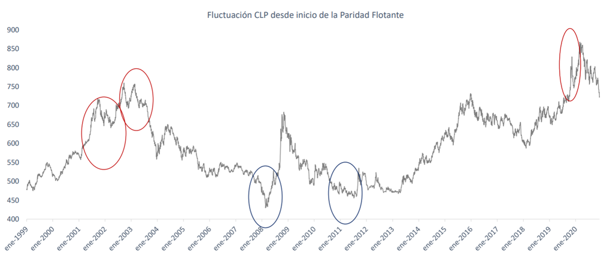

## Tipo de cambio real

El TCR mide el poder de compra de bienes entre países:

$$TCR = \frac{e \cdot P^*}{P}$$

Donde $e$ = tipo de cambio nominal, $P^*$ = nivel de precios internacional, $P$ = nivel de precios nacional.

Si Chile tiene más inflación que EE.UU. y el tipo de cambio nominal no se mueve, el peso se **aprecia en términos reales** — los productos chilenos se encarecen para el mundo.

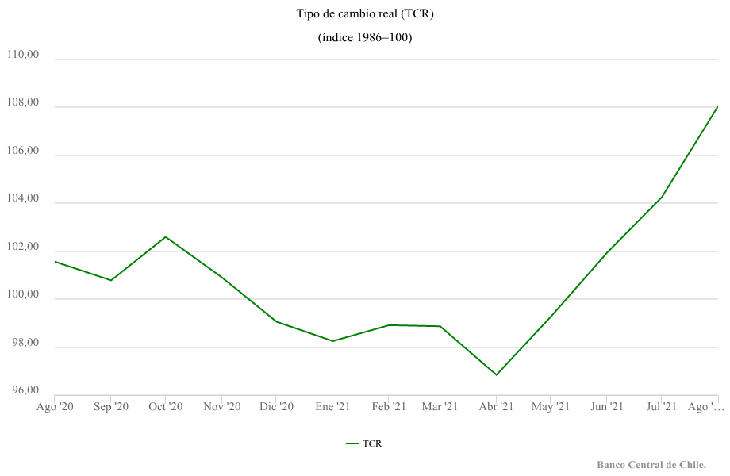

# Estabilidad financiera y holguras fiscales

## ¿Por qué mirar lo financiero y lo fiscal?

Actividad, empleo y precios describen cómo funciona la economía **hoy**.

La estabilidad financiera y la situación fiscal describen **cuánto margen hay para absorber shocks**: ¿pueden bancos, hogares, empresas y el Estado resistir un período de actividad débil y financiamiento más caro?

> Lo veremos con dos informes del Banco Central: el **IPoM** (actividad y precios) y el **IEF** (estabilidad financiera). Son la base de la actividad de coyuntura.

## Holguras fiscales

**Balance Estructural (BE):** déficit o superávit fiscal sin los efectos del ciclo económico ni del precio del cobre.

| Indicador | Dato |
| --- | --- |
| BE 2025 | **-3,6% del PIB** |
| Meta original 2025 | -1,1% del PIB |
| Desvío respecto a la meta | **2,5 pp del PIB** (US$8.863 millones) |
| Incumplimientos consecutivos | **3 años** (2023, 2024, 2025) |

Fuente: CFA, *Informe sobre el desvío de la meta de BE de 2025*, 4 de marzo de 2026, p. 4

**Deuda bruta del gobierno central**

| Indicador | Dato |
| --- | --- |
| Deuda / PIB, diciembre 2025 | **41,7%** |
| Deuda / PIB, marzo 2026 | **42,6%** |
| Nivel prudente de deuda | **45% del PIB** |
| Año en que superaría el 45% (escenario base) | **2029** (45,3%) |
| Deuda / PIB en 2007 | 3,9% → **×10 en 17 años** (41,7% en 2024) |

Fuentes: Banco Central, *IEF* 1S 2026, p. 25 (deuda 2025 y 2026); CFA, *Informe sobre BE y nivel prudente de deuda*, 17 de agosto de 2026, p. 17 (proyección); CFA, *Informe de BE 4T25*, 26 de marzo de 2026, p. 29 (2007 y 2024)

## Estabilidad financiera: ¿qué dice el IEF?

| Indicador | Dato |
| --- | --- |
| Principal riesgo | **Estrechamiento abrupto** de las condiciones de financiamiento (p. 4) |
| Banca: holgura de capital básico (CET1) | **3,2 pp** sobre los requerimientos; un estrés severo destruiría 2,3 pp (pp. 30 y 32) |
| Hogares: deuda | **46%** del PIB; riqueza financiera neta de 122% (p. 22) |
| Empresas: deuda no bancaria | **103%** del PIB (113% en 2024) (p. 19) |
| Inmobiliario | **19 meses** para agotar el stock de viviendas terminadas (7 en 2011–2019) (p. 22) |
| Deuda del gobierno central que vence en 5 años | **37%** (29% un año antes) (p. 25) |

Fuente: Banco Central de Chile, *Informe de Estabilidad Financiera*, primer semestre 2026 (cierre estadístico: 5 de mayo). Clasificación crediticia: Fitch ratificó **A− con perspectiva estable** el 18 de septiembre de 2026 (vía Ministerio de Hacienda).

> Actividad de coyuntura: ¿recesión, inflación o fragilidad financiera? Ver `clase01_actividad_04_coyuntura`

# Cierre

## Volvamos al titular

“US inflation tripled last month on record spike in gas prices”

Ahora pueden leer esto con precisión:

- **“Inflation”**: variación del IPC mensual — método Laspeyres, canasta fija
- **“Tripled”**: el *ritmo* mensual fue inusual (0,9%), no el nivel anual (3,3%)
- **“Gas prices”**: un bien que pesa ~3% de la canasta subió 21% → explica ~0,6 pp de los 0,9 pp del alza mensual (BLS: ficha de combustibles e informe CPI de marzo 2026)
- **Conexión con Chile**: el shock de petróleo mantiene el IPC local en torno a 4% en 2026, complica el Balance Estructural vía MEPCO, y presiona el tipo de cambio

## Lo que conecta todo

Los indicadores de esta clase no son compartimentos separados — se retroalimentan:

```
PIB crece    →   empleo sube   →   salarios nominales suben
                                         ↓
                              inflación sube si supera productividad
                                         ↓
                              salario real puede caer igual
                                         ↓
                         tipo de cambio y tasas de interés reaccionan
                                         ↓
                    finanzas públicas se ven afectadas (ingresos y gastos)
```

## Fechas relevantes

| Actividad | Detalle |
| --- | --- |
| Clase 1 | Generación de grupos |
| Clase 2 | Caso formativo en clases |
| Clase 3 | — |
| Clase 4 | Caso sumativo en clases |

## Fuentes y referencias (1/2)

- Banco Central de Chile. (2026, septiembre). *Informe de Política Monetaria*. bcentral.cl
- Banco Central de Chile. (2026, mayo). *Informe de Estabilidad Financiera, primer semestre 2026*. bcentral.cl
- INE Chile. (2026, 8 oct.). *Boletín estadístico: Índice de Precios al Consumidor, n° 335*. ine.cl
- CFA. (2026, 4 mar.). *Informe sobre el desvío de la meta de Balance Estructural de 2025*. cfachile.cl
- CFA. (2026, 26 mar.). *Informe de Balance Estructural y nivel prudente de deuda, 4T25*. cfachile.cl
- CFA. (2026, 17 ago.). *Informe sobre Balance Estructural y nivel prudente de deuda: estimaciones 2026-2030 del IFP del segundo trimestre de 2026*. cfachile.cl

## Fuentes y referencias (2/2)

- CNN Business. (2026, 10 abr.). *CPI report: US inflation tripled last month on record spike in gas prices*. [cnn.com](https://www.cnn.com/2026/04/10/business/live-news/us-cpi-march-inflation-iran)
- BLS. (2026, 10 abr.). *Consumer Price Index – March 2026*. [bls.gov](https://www.bls.gov/news.release/archives/cpi_04102026.htm)
- BLS. *Relative importance of motor fuel in the CPI*. [bls.gov](https://www.bls.gov/cpi/factsheets/motor-fuel.htm)
- Eurostat. (2025). *EU Labour Force Survey: annual data by sex and age* (tablas lfsa_pganws, lfsa_agan, lfsa_egan, lfsa_ugan). [ec.europa.eu/eurostat](https://ec.europa.eu/eurostat/web/lfs/database)
- Clark, A. & Oswald, A. (2002). A simple statistical method for measuring how life events affect happiness. *International Journal of Epidemiology*, 31(6), 1139–1144.
- Core Econ. *The Economy*. [core-econ.org](https://www.core-econ.org/the-economy/book/es/text/13.html)